# Assignment 1: Dataset Selection and Initial Processing

Evgeniya Gorobets

15 Feb 2022

## Preface

This R Notebook was developed by Evgeniya Gorobets as part of an assessment for 2022 BCB420H: Computational Systems Biology, University of Toronto, Toronto, CA. Specifically, this notebook was the final submitted product for Assignment 1 of the course.

This notebook only includes the download, cleaning, and processing of my selected GEO dataset. To view the code used to explore GEO, evaluate various GSEs, and ultimately select this dataset, see the R Notebook located at https://github.com/bcb420-2022/Evgeniya_Gorobets/blob/main/Assignment1/ExploringGEO.Rmd.

## Setup

```r
# Install required packages
if (!requireNamespace("colorRamps", quietly = TRUE)) {
  install.packages("colorRamps")
}
if (!requireNamespace("BiocManager", quietly = TRUE)) {
  install.packages("BiocManager")
}
if (!requireNamespace("GEOquery", quietly = TRUE)) {
    BiocManager::install("GEOquery")
}
```

```
## Setting options('download.file.method.GEOquery'='auto')
```

```
## Setting options('GEOquery.inmemory.gpl'=FALSE)
```

```r
if (!requireNamespace("edgeR", quietly = TRUE)) {
    BiocManager::install("edgeR")
}
if (!requireNamespace("biomaRt", quietly = TRUE)) {
    BiocManager::install("biomaRt")
}

# Change working directory, if needed
if (getwd() == "/home/rstudio") {
  setwd("./projects/Assignment1")
}

# Set constants
GSE <- 'GSE129943'
DATA_DIR <- 'data'
```

## Downloading the Data

Before beginning the data preparation, I check to make sure the counts data is available, and if not, I download it from GEO.

```r
gseDir <- paste0(DATA_DIR, "/", GSE)

# Download the supplemental files for GSE129943 if they're not yet in data dir
if (!file.exists(gseDir)) {
  dataFiles <- GEOquery::getGEOSuppFiles(GSE, baseDir=DATA_DIR)
  filePath <- rownames(dataFiles)
} else {
  filePath <- paste0(gseDir, "/", list.files(path=gseDir))
}

# Load supplemental files as a data frame
gseData <- read.delim(filePath, header=TRUE, check.names=FALSE)
# The columns that contain count data (useful for downstream analysis)
countsCols <- c("N1H1_Pool_1", "N1H1_Pool_2", "N1H1_Pool_3",
                "P1A8_Pool_1", "P1A8_Pool_2", "P1A8_Pool_3")
```

## Cleaning the Data

According to the `edgeR` protocol, the first step in cleaning the data is to remove weakly expressed genes. Specifically, we should filter out any genes that have less than one read per million (CPM) in n or more of the samples (where n is the size of the smallest group or replicates). Each group of replicates in our dataset has 3 samples, so we set n=3.

```r
# Part of this code block were based on Professor Isserlin's Lecture 4 slides
# (Isserlin, 2022)

nGenes <- length(unique(gseData$Ensembl))
cat(paste("Number of genes pre-filtering:", nGenes))  # 57,905
```

```
## Number of genes pre-filtering: 57905
```

```r
# Use edgeR to compute CPMs
cpms <- edgeR::cpm(gseData[, countsCols])
rownames(cpms) <- gseData$Ensembl

# Only keep genes with CPM > 1 in at least 3 of the samples
selectedGenes <- rowSums(cpms > 1) >= 3
gseData <- gseData[selectedGenes, ]

nGenes <- length(unique(gseData$Ensembl))
cat(paste("Number of genes post-filtering:", nGenes))  # 14,241
```

```
## Number of genes post-filtering: 14241
```

The second step of cleaning the data is to check for any duplicate genes.

```r
duplicateGenes <- table(gseData$Ensembl) > 1
length(gseData$Ensembl[duplicateGenes])
```

```
## [1] 0
```

Since there are no duplicate genes, then this section of our data cleaning is done.

## Normalizing the Data

Before we begin normalizing our data, we will first visualize the distribution of the raw data using a histogram and a boxplot.

```
## Warning in bplt(at[i], wid = width[i], stats = z$stats[, i], out = z$out[z$group
## == : Outlier (-Inf) in boxplot 4 is not drawn
```

```
## Warning in bplt(at[i], wid = width[i], stats = z$stats[, i], out = z$out[z$group
## == : Outlier (-Inf) in boxplot 5 is not drawn
```

```
## Warning in bplt(at[i], wid = width[i], stats = z$stats[, i], out = z$out[z$group
## == : Outlier (-Inf) in boxplot 6 is not drawn
```

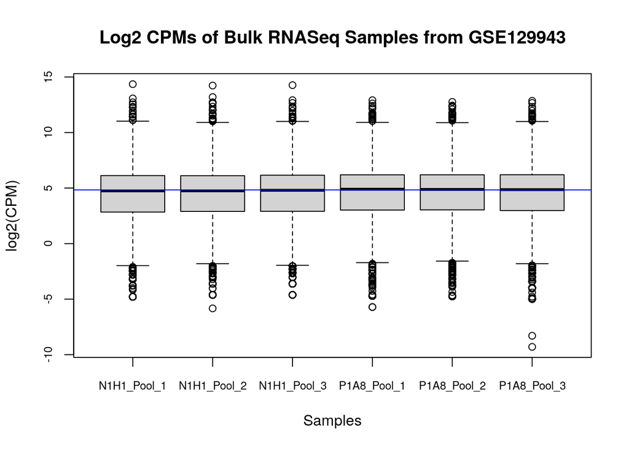

```r
# Part of this code block were based on Professor Isserlin's Lecture 4 slides
# (Isserlin, 2022)

# Helper function for computing the log2(cpm) of gene counts
getLogCpms <- function(counts) {
  cpms <- edgeR::cpm(counts)
  return(log2(cpms))
}

# Helper function to draw boxplot (we will need this again after normalization)
drawBoxplot <- function(logCPMs) {
  # Draw a boxplot representing the quartiles and outliers for each sample
  boxplot(logCPMs, xlab="Samples", ylab="log2(CPM)", cex.axis = 0.75,
          main=paste("Log2 CPMs of Bulk RNASeq Samples from", GSE))

  # Compute median log2(CPM) across all genes in all samples and plot it
  mediansPerSample <- apply(logCPMs, 2, median)
  cpmMedian <- median(mediansPerSample)
  abline(h=cpmMedian, col="blue")
}

# Draw a boxplot of the cleaned counts for our dataset
logCpms <- getLogCpms(gseData[, countsCols])
drawBoxplot(logCpms)
```

When creating the boxplots, I noticed some warning about outliers (-Inf) in some of the boxplots not being drawn. This indicates that some samples still have genes with CPM=0. However, we know that genes with CPM=0 in more than 3 samples have been removed, so we can safely ignore these warnings.

Next, we will plot the densities of the log2(CPM) for each sample.

```
## $N1H1_Pool_1
##
## Call:
##  density.default(x = newX[, i])
##
## Data: newX[, i] (14241 obs.);    Bandwidth 'bw' = 0.3235
##
##        x                 y
##  Min.   :-5.7607   Min.   :9.800e-07
##  1st Qu.:-0.4888   1st Qu.:1.800e-03
##  Median : 4.7832   Median :1.176e-02
##  Mean   : 4.7832   Mean   :4.718e-02
##  3rd Qu.:10.0551   3rd Qu.:7.992e-02
##  Max.   :15.3270   Max.   :1.831e-01
##
## $N1H1_Pool_2
##
## Call:
##  density.default(x = newX[, i])
##
## Data: newX[, i] (14241 obs.);    Bandwidth 'bw' = 0.3176
##
##        x                y
##  Min.   :-6.786   Min.   :1.030e-06
##  1st Qu.:-1.294   1st Qu.:9.048e-04
##  Median : 4.199   Median :8.939e-03
##  Mean   : 4.199   Mean   :4.530e-02
##  3rd Qu.: 9.691   3rd Qu.:7.707e-02
##  Max.   :15.184   Max.   :1.849e-01
##
## $N1H1_Pool_3
##
## Call:
##  density.default(x = newX[, i])
##
## Data: newX[, i] (14241 obs.);    Bandwidth 'bw' = 0.3193
##
##        x                y
##  Min.   :-5.574   Min.   :9.900e-07
##  1st Qu.:-0.375   1st Qu.:1.702e-03
```

[output cut: 34 more lines]

```
##
## $P1A8_Pool_3
##
## Call:
##  density.default(x = newX[, i])
##
## Data: newX[, i] (14241 obs.);    Bandwidth 'bw' = 0.3174
##
##        x                 y
##  Min.   :-10.252   Min.   :0.0000000
##  1st Qu.: -4.237   1st Qu.:0.0002946
##  Median :  1.778   Median :0.0050428
##  Mean   :  1.778   Mean   :0.0413778
##  3rd Qu.:  7.794   3rd Qu.:0.0714256
##  Max.   : 13.809   Max.   :0.1901305
```

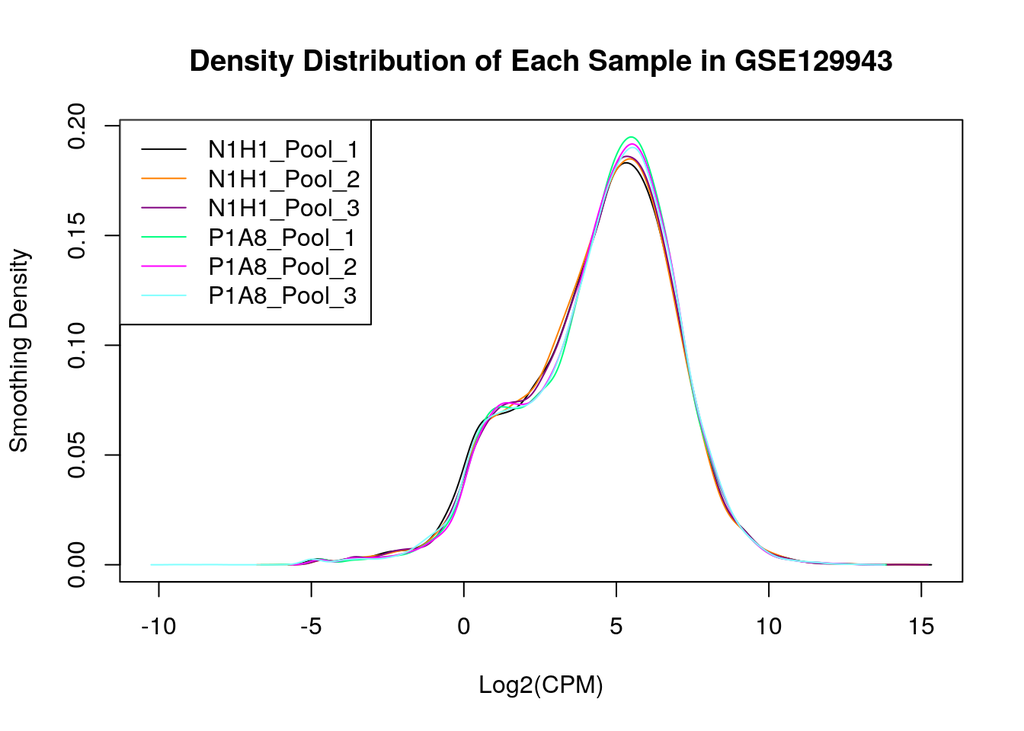

```r
# Part of this code block were based on Professor Isserlin's Lecture 4 slides
# (Isserlin, 2022)

# Helper function to draw the distribution of each sample
# (we will need this again after normalization)
drawDensities <- function(logCPMs, title) {
  # Get the density distribution of each sample
  densityPerSample <- apply(logCPMs, 2, density)
  print(densityPerSample)

  # Helper to get density stats across all samples
  getDensityStat <- function(samples, stat, axis) {
    statPerSample <- lapply(samples, function(sample) { stat(sample[[axis]]) })
    return(stat(unlist(statPerSample)))
  }

  # Get x and y limits across all density plots
  minX <- getDensityStat(densityPerSample, min, 'x')
  minY <- getDensityStat(densityPerSample, min, 'y')
  maxX <- getDensityStat(densityPerSample, max, 'x')
  maxY <- getDensityStat(densityPerSample, max, 'y')

  numSamples <- ncol(logCPMs)
  lineColors <- colorRamps::primary.colors(numSamples)

  # Initialize an empty plot
  plot(c(), xlim=c(minX, maxX), ylim=c(minY, maxY), type="n",
       xlab="Log2(CPM)", ylab="Smoothing Density", main=title)

  # Draw each density line on the plot
  for (i in seq_along(densityPerSample)) {
    lines(densityPerSample[[i]], col=lineColors[i], lty=1)
  }

  # Create a legend
  legend("topleft", legend=colnames(logCPMs), col=lineColors,
         lty=rep(1, numSamples))
}

title <- paste("Density Distribution of Each Sample in", GSE)
drawDensities(logCpms, title)
```

We note that none of our samples have a clear normal distribution. All of them have a “hump” on their left side. Ideally, we would want normalization to remove that hump.

Before choosing a normalization method, we consider the assumptions we can make about our data. There are two primary questions about the data that affect the normalization method we choose (Evans, Hardin, & Stoebel, 2018):

1. Do the two biological conditions (normal kidney cells vs. kidney cells from MKD patients) have the same total mRNA/cell?
2. Is the number of differentially expressed genes in the two biological conditions roughly the same? (Is the differential expression symmetric?)

MKD is a proteinopathy caused by a frameshift mutation in the MUC1 gene, often due to the insertion of an extra cytosine. The length of the MUC1 gene is thus roughly the same in all samples. The promoter for wild-type MUC1 and fs-MUC1 is the same, so we expect the quantity of MUC1 mRNA to be roughly the same in all samples as well. However, the study that produced this dataset noted that in MKD cells, there was increased activation of unfolded protein response (UPR), and in particular, of the ATF5 branch of UPR (relative to normal kidney cells). The authors of the study confirmed this observation not only through RNASeq results but also through Immunoblot and RT-PCR analysis of downstream effectors of the three UPR branches. Therefore, it is reasonable to expect that the MKD samples in this dataset will have more UPR-related transcripts than the normal kidney samples. There was no evidence or mention in the study that the upregulation of UPR-related genes in MKD cells was paired with the downregulation of other genes. This suggests that the total mRNA/cell may be greater in MKD cells compared to normal human kidney cells. Therefore, normalization techniques that normalize by library size (such as total count normalization, RPKM, FPKM, etc.) are unsuitable for the dataset, since these methods rely on the assumption that the total mRNA/cell stays the same across all samples (Evans, Hardin, & Stoebel, 2018).

We will also eliminate “normalization by controls” as a normalization strategy. Since it is unclear which housekeeping genes would be unaffected by MKD and since no spike-ins were used in this sequencing experiment, then there are no control genes that can be used to normalize the sample.

This leaves us with normalization by distribution (quantile normalization, TMM, MRN, DESeq normalization, etc.) or normalization by testing (PoissonSeq, DEGES, etc.). All normalization methods that fall into this category try to estimate which genes are non-DE and use that to compute the total mRNA/cell in each sample (Evans, Hardin, & Stoebel, 2018). In order to identify the non-DE genes, these methods assume that the samples have mostly symmetrical differential expression (Evans, Hardin, & Stoebel, 2018). I am particularly interested in TMM, because it has been reported to have good results on real and simulated datasets.

Based on the observations we have already made about the upregulation of UPR in MKD cells, we know that differential expression is not completely symmetrical between our two conditions. However, since UPR activation only involves a few genes, it is likely that our dataset’s asymmetry is within the the allowable threshold for TMM to work. The study that produced this dataset made no suggestion that there might be a global shift in expression between normal cells and MKD cells; therefore, I will assume that the differential expression of this dataset is symmetrical enough such that TMM can still normalize counts for the total mRNA/cell in samples.

```r
# Part of this code block were based on Professor Isserlin's Lecture 4 slides
# (Isserlin, 2022)

# Convert counts columns in GSE to a matrix
countsMatrix <- as.matrix(gseData[, countsCols])
rownames(countsMatrix) <- gseData$Ensembl

# Get the cell type of each sample
cellTypeList <- lapply(strsplit(colnames(countsMatrix), "_"),
                       function(split) {split[1]})
cellTypes <- unlist(cellTypeList)
names(cellTypes) <- colnames(countsMatrix)

# TMM Normalization
dge <- edgeR::DGEList(counts=countsMatrix, group=cellTypes)
dge <- edgeR::calcNormFactors(dge, method="TMM")
# NOTE: the above function only changes the norm.factors column
```

Now that I have normalized the counts, I want to reexamine the distribution of the data.

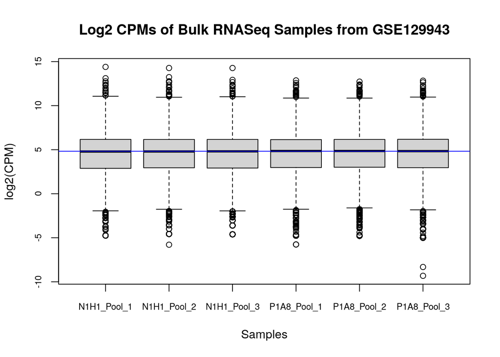

```r
# Draw a boxplot of the normalized counts
# NOTE: you can pass a DGEList object to edgeR::cpm and it will factor in the
# normalization factors
logCpmsNorm <- getLogCpms(dge)
drawBoxplot(logCpmsNorm)
```

```
## $N1H1_Pool_1
##
## Call:
##  density.default(x = newX[, i])
##
## Data: newX[, i] (14241 obs.);    Bandwidth 'bw' = 0.3235
##
##        x                 y
##  Min.   :-5.7177   Min.   :9.800e-07
##  1st Qu.:-0.4457   1st Qu.:1.800e-03
##  Median : 4.8262   Median :1.176e-02
##  Mean   : 4.8262   Mean   :4.718e-02
##  3rd Qu.:10.0981   3rd Qu.:7.992e-02
##  Max.   :15.3701   Max.   :1.831e-01
##
## $N1H1_Pool_2
##
## Call:
##  density.default(x = newX[, i])
##
## Data: newX[, i] (14241 obs.);    Bandwidth 'bw' = 0.3176
##
##        x                y
##  Min.   :-6.741   Min.   :1.030e-06
##  1st Qu.:-1.249   1st Qu.:9.048e-04
##  Median : 4.244   Median :8.939e-03
##  Mean   : 4.244   Mean   :4.530e-02
##  3rd Qu.: 9.736   3rd Qu.:7.707e-02
##  Max.   :15.229   Max.   :1.849e-01
##
## $N1H1_Pool_3
##
## Call:
##  density.default(x = newX[, i])
##
## Data: newX[, i] (14241 obs.);    Bandwidth 'bw' = 0.3193
##
##        x                 y
##  Min.   :-5.5652   Min.   :9.900e-07
##  1st Qu.:-0.3658   1st Qu.:1.702e-03
```

[output cut: 34 more lines]

```
##
## $P1A8_Pool_3
##
## Call:
##  density.default(x = newX[, i])
##
## Data: newX[, i] (14241 obs.);    Bandwidth 'bw' = 0.3174
##
##        x                 y
##  Min.   :-10.273   Min.   :0.0000000
##  1st Qu.: -4.258   1st Qu.:0.0002946
##  Median :  1.758   Median :0.0050428
##  Mean   :  1.758   Mean   :0.0413778
##  3rd Qu.:  7.773   3rd Qu.:0.0714256
##  Max.   : 13.788   Max.   :0.1901305
```

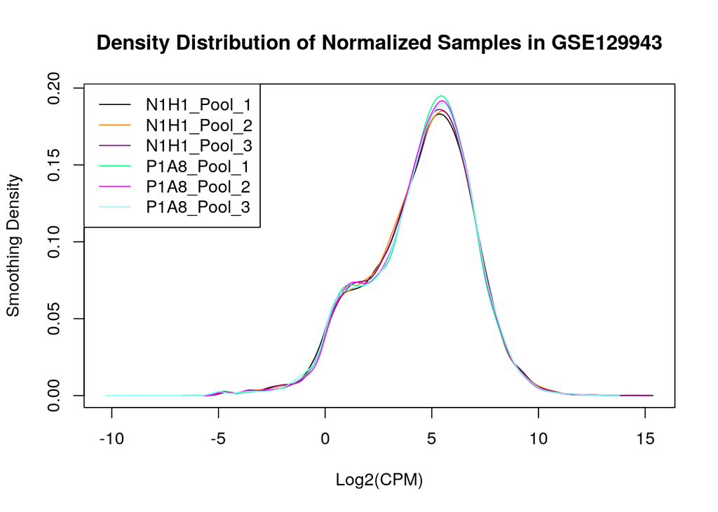

```r
title <- paste("Density Distribution of Normalized Samples in", GSE)
drawDensities(logCpmsNorm, title)
```

Both the boxplot and the density plots look almost exactly the same for our pre-TMM and post-TMM data. We notice that there is still a hump in the side of each sample. However, if we examine the density statistics printed for each sample, we notice that there are small changes in the mean, median, range, and quartiles for each sample. For instance, the mean log2(CPM) in P1A8_Pool_3 was 1.778 pre-TMM and 1.758 post-TMM. Similarly, a quick check of the log2(CPMs) for the first gene before and after TMM reveal that the normalization did have some effect.

```r
geneCounts <- rbind(logCpms[1, ], logCpmsNorm[1, ],
                    logCpmsNorm[1, ] - logCpms[1, ])
rownames(geneCounts) <- c("Pre-TMM", "Post-TMM", "Difference")
print(geneCounts)
```

```
##            N1H1_Pool_1 N1H1_Pool_2 N1H1_Pool_3 P1A8_Pool_1 P1A8_Pool_2
## Pre-TMM      6.3677832  6.32755878 6.166648530  5.90446577  5.89075329
## Post-TMM     6.4108236  6.37229611 6.175845098  5.85764585  5.86125604
## Difference   0.0430404  0.04473733 0.009196568 -0.04681991 -0.02949725
##            P1A8_Pool_3
## Pre-TMM     5.89708073
## Post-TMM    5.87642360
## Difference -0.02065713
```

We notice that the difference in log2(CPM) between pre- and post-normalization is non-zero for each sample. Specifically, all the log2(CPMs) in normal kidney samples were increased during TMM while all the log2(CPMs) in MKD samples were decreased. We can thus conclude that our normalization was effective.

## Exploring the Data

### Sample Separation - MDS Plot

To better understand our data, I will see how good the sample separation in this dataset is.

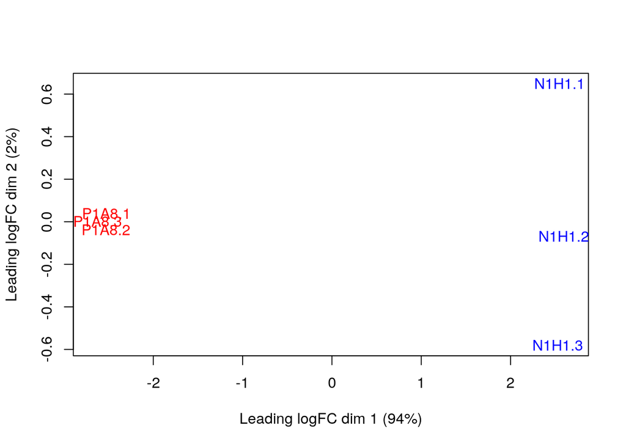

```r
# Part of this code block were based on Professor Isserlin's Lecture 5 slides
# (Isserlin, 2022)

# For readability, shorten the sample names
sampleNames <- rownames(dge$samples)
sampleNames <- lapply(strsplit(sampleNames, "_"), function(split) {
  return(paste0(split[1], ".", split[3]))
})
sampleNames <- unlist(sampleNames)

# Create MDS plot
edgeR::plotMDS.DGEList(dge, labels=sampleNames,
                       col=c(rep("blue", 3), rep("red", 3)))
```

I notice extremely good separation between the two biological conditions, specifically in the first dimension. I notice strong clustering of the MKD samples (red), which is promising. The normal kidney samples are very similar in dimension 1 but have some separation in dimension 2.

### Variance, Dispersion, and BCV

```r
# Part of this code block were based on Professor Isserlin's Lecture 4 slides
# (Isserlin, 2022)
dge <- edgeR::estimateDisp(dge)
```

```
## Using classic mode.
```

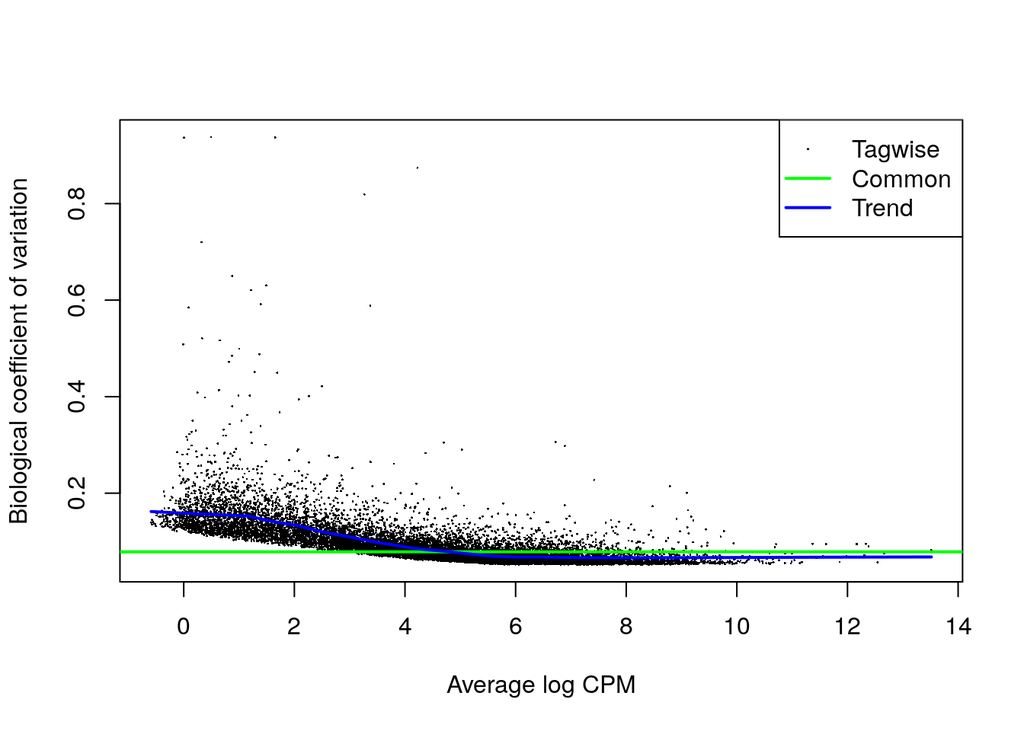

```r
# Plot BCV (dispersion squared), both tagwise and common
edgeR::plotBCV(dge, col.tagwise="black", col.common="green")
```

As expected, the highest BCV (variation) is found in genes that have low expression. Beyond that, the BCV plot looks typical.

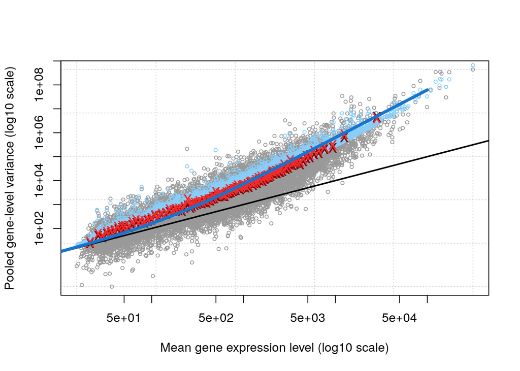

```r
# Part of this code block were based on Professor Isserlin's Lecture 4 slides
# (Isserlin, 2022)
edgeR::plotMeanVar(dge, show.raw.vars=T, show.tagwise.vars=T, NBline=T,
                   show.ave.raw.vars=T, show.binned.common.disp.vars=T)
```

The mean-to-variance plot also looks fairly typical, and will be more useful in downstream analysis.

## Mapping Gene Identifiers

The final step in the dataset preparation is to map the gene IDs to HUGO symbols. First, we note that our dataset already came with HGNC symbols.

```r
originalMappings <- gseData[, c("Ensembl", "HGNC")]
length(which(is.na(originalMappings$HGNC)))
```

```
## [1] 360
```

```r
length(which(originalMappings$HGNC == ""))
```

```
## [1] 962
```

However, of these gene symbols, 360 are `NA` and 962 are empty strings. To make it easier to identify missing mappings, I will replace all empty strings with `NA`s.

```r
originalMappings$HGNC[originalMappings$HGNC == ""] <- NA
length(which(is.na(originalMappings$HGNC)))
```

```
## [1] 1322
```

Because so many gene symbol mappings are missing from my dataset, and because I wish to verify the mappings, I will use `biomaRt` to remap the ENSEMBL IDs to HUGO gene symbols.

```r
mappingsFile <- paste0(DATA_DIR, "/geneMappings.rds")
tryDiffMarts <- !file.exists(mappingsFile)
```

*NOTE: The following, collapsed portion of the notebook was used to evaluate the best dataset to use for mapping ENSEMBL gene IDs to HGNC symbols. If the mappings file is already available, then any code in this block will not be evaluated in order to save computational time and avoid dealing with possible Ensembl timeouts.*

**Click to expand**

Since this dataset was published to GEO on April 17, 2019, I will try mapping with both the most recent version of Ensembl and the version that was most recent in April 2019. Unfortunately, the publication associated with this dataset did not specify which Ensembl version they used.

```r
ensemblVersions <- biomaRt::listEnsemblArchives()

# Get all the ENSEMBL version published in 2019 or 2018
ensemblVersions[grepl("(2019)|(2018)", ensemblVersions$date), ]
```

|  | name | date | url | version | current_release |
| --- | --- | --- | --- | --- | --- |
| 9 | Ensembl 98 | Sep 2019 | https://sep2019.archive.ensembl.org | 98 |  |
| 10 | Ensembl 97 | Jul 2019 | https://jul2019.archive.ensembl.org | 97 |  |
| 11 | Ensembl 96 | Apr 2019 | https://apr2019.archive.ensembl.org | 96 |  |
| 12 | Ensembl 95 | Jan 2019 | https://jan2019.archive.ensembl.org | 95 |  |
| 13 | Ensembl 94 | Oct 2018 | https://oct2018.archive.ensembl.org | 94 |  |
| 14 | Ensembl 93 | Jul 2018 | https://jul2018.archive.ensembl.org | 93 |  |
| 15 | Ensembl 92 | Apr 2018 | https://apr2018.archive.ensembl.org | 92 |  |

Ensembl 96 was published in April 2019, so it could not have been used for data analysis. I will try Ensembl 95, which was published in January 2019, and Ensembl 94, which was published in October 2018.

```r
humanDataset <- "hsapiens_gene_ensembl"

# Connect to ENSEMBL gene marts, human dataset
# At the time this was written, version 105 was the most current Ensembl release
ensembl105 <- biomaRt::useEnsembl("genes", dataset=humanDataset, version=105)
```

```
## Ensembl site unresponsive, trying useast mirror
```

```r
ensembl95 <- biomaRt::useEnsembl("genes", dataset=humanDataset, version=95)
ensembl94 <- biomaRt::useEnsembl("genes", dataset=humanDataset, version=94)
```

Since there are multiple ENSEMBL-related filters, I will first double check the types of ENSEMBL IDs that I have in my dataset

```r
# Check that all ENSEMBL IDs are gene IDs (not transcript/peptide IDs)
all(grepl("^ENSG", gseData$Ensembl))
```

```
## [1] TRUE
```

```r
# Check whether any of the ENSEMBL gene IDs have version numbers
any(grepl("\\.", gseData$Ensembl))
```

```
## [1] FALSE
```

Since all my ENSEMBL IDs are gene IDs and none of them have version numbers, then I will use the `ensembl_gene_id` filter.

```r
# Helper to compute stats on mappings
printMappingStats <- function(mapping, mapName, ogMappings) {
  # Remove any empty strings
  emptySymbols <- mapping$hgnc_symbol == ""
  mapping <- mapping[!emptySymbols, ]
  cat(paste("Removed", sum(emptySymbols), "empty HUGO symbols from",
            mapName, "mapping.\n"))

  # Get number of unique ENSEMBL IDs that were mapped
  numMappedGenes <- length(unique(mapping$ensembl_gene_id))
  # Get number of genes that were mapped to more than one symbol
  numMappedMultiple <- sum(table(mapping$ensembl_gene_id) > 1)

  # Compare to original mappings
  joinedMappings <- merge(mapping, ogMappings, by.x='ensembl_gene_id',
                          by.y='Ensembl',  all.y=T)
  numUnmappedGenes <- sum(is.na(joinedMappings$hgnc_symbol))

  # Number of mappings that are different
  diffSymbols <- joinedMappings$hgnc_symbol != joinedMappings$HGNC
  nonNullSymbols <-
    !is.na(joinedMappings$hgnc_symbol) & !is.na(joinedMappings$HGNC)
  numDiffSymbols <- sum(diffSymbols & nonNullSymbols)

  # Print results
  cat(
    paste(mapName, "Mapping Stats:"),
    paste("Number of genes mapped:", numMappedGenes),
    paste("Number of genes mapped to multiple symbols:", numMappedMultiple),
    paste("Number of genes not mapped to any symbols:", numUnmappedGenes),
    paste("Number of genes mapped to different symbols relative to original",
          "mappings:", numDiffSymbols),
    "\n",
    sep="\n")
}
```

```r
# Helper function to get HGNC symbols for a set of ENSEMBL gene IDs with a
# given mart
mapGeneIds <- function(ensemblIDs, mart) {
  mappings <- biomaRt::getBM(attributes=c("ensembl_gene_id", "hgnc_symbol"),
                             filters=c("ensembl_gene_id"),
                             values=ensemblIDs,
                             mart=mart)
  return(mappings)
}

# Get mappings using each mart
mappings105 <- mapGeneIds(gseData$Ensembl, ensembl105)
mappings95 <- mapGeneIds(gseData$Ensembl, ensembl95)
mappings94 <- mapGeneIds(gseData$Ensembl, ensembl94)

mappings <- list(mappings105, mappings95, mappings94)
names(mappings) <- c("Ensembl 105", "Ensembl 95", "Ensembl 94")

# Print stats for each mapping
for (i in seq_along(mappings)) {
  printMappingStats(mappings[[i]], names(mappings)[i], originalMappings)
}
```

```
## Removed 462 empty HUGO symbols from Ensembl 105 mapping.
## Ensembl 105 Mapping Stats:
## Number of genes mapped: 13435
## Number of genes mapped to multiple symbols: 1
## Number of genes not mapped to any symbols: 806
## Number of genes mapped to different symbols relative to original mappings: 1127
##
##
## Removed 598 empty HUGO symbols from Ensembl 95 mapping.
## Ensembl 95 Mapping Stats:
## Number of genes mapped: 13329
## Number of genes mapped to multiple symbols: 0
## Number of genes not mapped to any symbols: 912
## Number of genes mapped to different symbols relative to original mappings: 942
##
##
## Removed 608 empty HUGO symbols from Ensembl 94 mapping.
## Ensembl 94 Mapping Stats:
## Number of genes mapped: 13319
## Number of genes mapped to multiple symbols: 0
## Number of genes not mapped to any symbols: 922
## Number of genes mapped to different symbols relative to original mappings: 934
```

Unfortunately, none of the ENSEMBL versions had perfect gene symbol mapping. The version that mapped the most genes was the newest release of ENSEMBL (105) (It mapped more than 100 genes more than the second best version), so this is the one I will use for the rest of this course.

```r
# Remove remnants of other mapping attempts to avoid confusion
rm(mappings95, mappings94, ensembl94, ensembl95)
saveRDS(mappings105, mappingsFile)
```

```r
geneIdMappings <- readRDS(mappingsFile)
# The printMappingStats function is defined in the collapsible section of
# this notebook
printMappingStats(geneIdMappings, "Ensembl 105", originalMappings)
```

```
## Removed 462 empty HUGO symbols from Ensembl 105 mapping.
## Ensembl 105 Mapping Stats:
## Number of genes mapped: 13435
## Number of genes mapped to multiple symbols: 1
## Number of genes not mapped to any symbols: 806
## Number of genes mapped to different symbols relative to original mappings: 1127
```

First, I want to investigate the gene that was mapped to more than one symbol.

```r
freq <- table(geneIdMappings$ensembl_gene_id)
duplicateGene <- names(freq[freq > 1])
geneIdMappings[geneIdMappings$ensembl_gene_id == duplicateGene, ]
```

|  | ensembl_gene_id | hgnc_symbol |
| --- | --- | --- |
| 13334 | ENSG00000254876 | SUGT1P4-STRA6LP |
| 13335 | ENSG00000254876 | STRA6LP |

The gene ENSG00000254876 was mapped to both SUGT1P4-STRA6LP and STRA6LP. According to the [HGNC](https://www.genenames.org/data/gene-symbol-report/#!/hgnc_id/HGNC:53830), STRA6LP is a pseudogene, while SUGT1P4-STRA6LP is an approved gene in the human genome (Howe et al, 2021). I will thus stick to SUGT1P4-STRA6LP and remove STRA6LP from mymappings table.

```r
geneIdMappings <- geneIdMappings[geneIdMappings$hgnc_symbol != "STRA6LP", ]
printMappingStats(geneIdMappings, "Ensembl 105", originalMappings)
```

```
## Removed 462 empty HUGO symbols from Ensembl 105 mapping.
## Ensembl 105 Mapping Stats:
## Number of genes mapped: 13435
## Number of genes mapped to multiple symbols: 0
## Number of genes not mapped to any symbols: 806
## Number of genes mapped to different symbols relative to original mappings: 1127
```

Now that all genes only map to one symbol, I want to remove any genes that map to empty strings, of which there are 462.

```r
geneIdMappings <- geneIdMappings[geneIdMappings$hgnc_symbol != "", ]
printMappingStats(geneIdMappings, "Ensembl 105", originalMappings)
```

```
## Removed 0 empty HUGO symbols from Ensembl 105 mapping.
## Ensembl 105 Mapping Stats:
## Number of genes mapped: 13435
## Number of genes mapped to multiple symbols: 0
## Number of genes not mapped to any symbols: 806
## Number of genes mapped to different symbols relative to original mappings: 1127
```

I notice that quite a few (1127) of the HGNC symbols I retrieved from Biomart do not align with the HGNC symbols that were in the original dataset. This is likely due to an error in the study or a different Ensembl version. This disparity between HUGO identifiers suggests that I should not attempt to fill in the missing symbols in my mapping table with symbols from the original dataset. However, I can use the HGNC symbols from the original dataset to gain insight to my unmapped genes.

```r
# Replace original HGNC mappings with the ones I retrieved
gseData <- merge(
  geneIdMappings, gseData, by.x='ensembl_gene_id', by.y='Ensembl', all.y=T)
colnames(gseData)[colnames(gseData) == "ensembl_gene_id"] <- "Ensembl"

# Identify unmapped genes
unmappedRows <- is.na(gseData$hgnc_symbol)
unmappedGenes <- gseData[unmappedRows, c("Ensembl", "HGNC", "hgnc_symbol")]

# What percentage of genes are unmapped?
100 * nrow(unmappedGenes) / nrow(gseData)
```

```
## [1] 5.659715
```

806 of 14,241 genes are unmapped. This corresponds to 5.66% of all the genes in my dataset. First, I check whether the unmapped genes are ribosomal proteins, which do not affect differential expression analysis.

```r
# How many are ribosomal proteins?
length(grep("^RP", unmappedGenes$HGNC))
```

```
## [1] 4
```

Only 4 of the unmapped genes are ribosomal proteins, so there are 802 other genes that are unmapped. To try and investigate, I will look up the first few unmapped genes in the Ensembl database.

```r
head(unmappedGenes)
```

|  | Ensembl | HGNC | hgnc_symbol |
| --- | --- | --- | --- |
| 93 | ENSG00000005955 | GGNBP2 | NA |
| 102 | ENSG00000006114 | SYNRG | NA |
| 288 | ENSG00000017621 | MAGIX | NA |
| 397 | ENSG00000034063 | UHRF1 | NA |
| 600 | ENSG00000056661 | PCGF2 | NA |
| 845 | ENSG00000068793 | CYFIP1 | NA |

For each of the six gene IDs above, an ENSEMBL search revealed that these have been deprecated since ENSEMBL Version 76 (i.e., version 75 was the last to contain these gene identifiers) (Howe et al, 2021). This strongly suggests that the authors of this dataset used Ensembl version 75 or less when creating this dataset.

However, using such an old version of gene identifiers is ill-advised, as it may cause me to lose out on newer gene annotations, which may impact my downstream analysis (especially in gene set enrichment). Therefore, I will stick to my HGNC symbols (rather than the ones from the original dataset), but I will not remove the unmapped genes. If in later analysis, the unmapped genes are significant (i.e., they turn out to be differentially expressed), then I will explore those genes further and see if they have more modern identifiers in Ensembl that do map to HUGO gene symbols.

As a result of this decision, the final product of my notebook is not a data frame with only numeric columns and unique HUGO symbols, but a data frame with unique gene identifiers, some of which lack HUGO symbols.

```r
# Remove old HGNC symbols
gseData <- gseData[, names(gseData) != "HGNC"]

# Save data
# cnm = cleaned, normalized, mapped
dataPath <- paste0(DATA_DIR, "/cnmData.rds")
saveRDS(gseData, dataPath)
```

## Conclusion

Below is a summary of the key features of my dataset, posed as seven questions.

1. What are the control and test conditions of the dataset?

The control condition is normal human kidney cells (with the MUC1-wt allele). The test condition are kidney cells from MKD patiens (with the MUC1-fs allele).

2. Why is the dataset of interest to you?

This dataset is of interest to me because it is part of a larger interesting study in which the authors identified a therapy (BRD4780) that may help cure many proteinopathies which previously had no cure. I also have no experience with kidney-related biology, so this dataset is introducing me to genes and pathways that I am curious about.

3. Were there expression values that were not unique for specific genes? How did you handle these?

There were no duplicate Ensembl gene IDs, but there was one gene ID that mapped to two different HUGO symbols. I resolved this by researching the two HUGO symbols and selecting the one that was approved for the human genome (rather than the pseudogene).

4. Were there expression values that could not be mapped to current HUGO symbols?

As addressed in the section on Identifier Mapping, about 5.66% of the genes could not be mapped to current HUGO symbols, most likely because the authors of the dataset used Ensembl version 75 (from Feb 2014). For now, I have left these genes in the data, and I have resolved to investigate them further if they turn out to be differentially expressed.

5. How many outliers were removed?

No outliers seemed significant and therefore none were removed.

6. How did you handle replicates?

Because all the samples came from different patients, no special handling of the replicates was required. I simply made sure to filter out genes that had low expression in more than 3 samples, since the number of replicates was 3 in each condition.

7. What is the final coverage of your dataset?

Because I did not remove any of the unmapped genes, the final coverage of my dataset was 14,241 human genes.

## Clean-Up

```r
# Clear workspace
rm(list = ls())
```

## References

Evans, C., Hardin, J., & Stoebel, D.M. 2018. Selecting between-sample RNA-Seq normalization methods from the perspective of their assumptions. *Briefings in Bioinformatics 19*(5), pgs. 776–792. https://doi.org/10.1093/bib/bbx008

Howe, K.L, et al. 2021. Ensembl 2021. *Nucleic Acids Research 49*(D1), pgs. D884–D891. https://doi.org/10.1093/nar/gkaa942

Isserlin, R. (2022). Lecture 5 - Data Exploration and Identifier Mapping. Quercus. https://q.utoronto.ca/courses/248455/files/18120883?module_item_id=3463354

Isserlin, R. (2022). Lecture 4 - Data Exploration and Normalization. Quercus. https://q.utoronto.ca/courses/248455/files/19273570?module_item_id=3476594